# Finding the optimal location for a fitness center in Aarhus

Sofie Thinggaard

07/06/2022

#Prepre R

Run relevant packages

```r
library(sf)
library(dplyr)
library(plyr)
library(purrr)
library(osmdata)
```

```r
library(ggplot2)
library(tidyverse)
library(magrittr)
library(ggmap)
library(stringr)
library(RSelenium)
library(geojsonR)
library(geojsonio)
```

Datasets made in this markdown file:

```r
#load("data/data_gym.rda") #OSM fitness center data without NAs and duplicates and flipped long lat coordinates + the parishes it is located in + additional found fitness centers
#load("data/data_sogn_fin.rda") #number of fitness centers in each parish and how many in the target group lives there
#load("data/aarhus_mun.rda") #parishes ONLY in Aarhus municipality (for the parish boarders of the map)
#load("data/target_gym_parish.rda") #the number of target group per fitness center in the parish
```

## Get all gyms from openstreetmap

With Openstreetmap we can get all fitness centers/gyms in Aarhus by their ‘fitness-centre’-tag with “leisure” as key

Other tags I tried:

- **leisure=sports_centre**: this returns 800 results in Aarhus, but it is places like roklubber (rowing clubs). Not what I am after.
- **sport=crossfit:** returns zero results in Aarhus
- **sport=pilates:** returns zero results in Aarhus
- **sport=yoga:** returns zero results in Aarhus

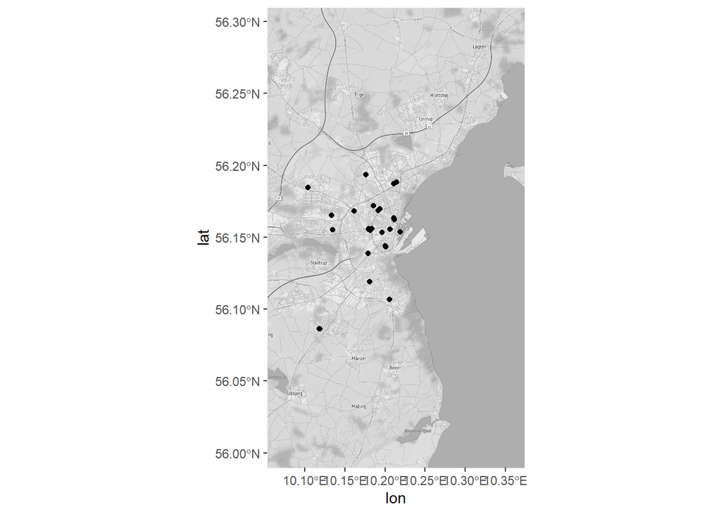

```r
# The following code is based on this vignette
# https://cran.r-project.org/web/packages/osmdata/vignettes/osmdata.html

# In this code I use the package "osmdata" to download data from OSM

# Step (1): Find an area of interest
# The area is defined as a bounding box so get coordinates from OSM
#https://www.openstreetmap.org/relation/1784663#map=10/56.1635/10.1692

# The bbox - square boundary box is defined in this way
# c(xmin,ymin,xmax,ymax) - where x is longitude and y is latitude

# Step (2): Build up the call to Overpass API
# Firstly: the box
call <- opq(bbox = c(9.7,56.2,10.6,56.0))

# Second is the feature of interest (the tag)
call <- add_osm_feature(call, key = "leisure",value=c("fitness_centre"))

# Step (3): Make the query/call to Overpass API
mydata <- osmdata_sf(call)
mad_map <- get_map(getbb("Aarhus"), maptype="roadmap",source="osm",color="bw")
#plot to see map of the fitness centers OSM has found:
ggmap(mad_map)+
  geom_sf(data = mydata$osm_points,
          inherit.aes = FALSE)
```

Convert to dataframe and look at data points

```r
data <- as.data.frame(mydata$osm_points)

#number of observations
nrow(data)
```

```
## [1] 35
```

```r
#labels in the dataset
labels(data)
```

```
## [[1]]
##  [1] "1945583629" "1945583653" "1945583661" "1945583666" "1945583672"
##  [6] "3096058127" "4455806490" "4732066407" "4732066408" "4732066409"
## [11] "4732066410" "5664554632" "5671442252" "5676162578" "5681193814"
## [16] "5681193815" "5684477545" "5686106272" "5686106274" "5692297927"
## [21] "6168655141" "6168655165" "6168655177" "6168655194" "6360263198"
## [26] "6970617423" "8401697108" "9276164205" "9278394205" "9645234918"
## [31] "9645234940" "9645234942" "9650455592" "9650458417" "9654241978"
##
## [[2]]
##  [1] "osm_id"             "name"               "branch"
##  [4] "brand"              "brand.wikidata"     "brand.wikipedia"
##  [7] "description"        "fvst.name"          "fvst.navnelbnr"
## [10] "leisure"            "opening_hours"      "ref"
## [13] "ref.DK.cvr"         "ref.DK.cvr.pnummer" "sport"
## [16] "website"            "wheelchair"         "geometry"
```

```r
#names of the fitness centers
data$name
```

```
##  [1] "Fitness World"
##  [2] "Fitness World Ã…rhus Jens Baggesens Vej"
##  [3] "Fitness World"
##  [4] "Fitness World Scandinavian"
##  [5] "Fitness World"
##  [6] "Fitness World"
##  [7] "Fit&Sund"
##  [8] NA
##  [9] NA
## [10] NA
## [11] NA
## [12] NA
## [13] "Aarhus Crossfit"
## [14] "SATS"
## [15] "Fitness World - Ã…rhus N. Vejlby"
```

[output cut: 20 more lines]

We see that we need to do some data processing, because some of the fitness centers do not have addresses and the coordinates are written wrong (we need to flip long and lat). We are interested in getting the addresses to find out which parish they are placed in.

Rearrange coordinates:

```r
#take a look at the coordinates as they are now
data$geometry
```

```
## Geometry set for 35 features
## Geometry type: POINT
## Dimension:     XY
## Bounding box:  xmin: 9.930533 ymin: 56.03366 xmax: 10.21896 ymax: 56.19365
## Geodetic CRS:  WGS 84
## First 5 geometries:
```

```
## POINT (10.10428 56.18446)
```

```
## POINT (10.19371 56.16966)
```

```
## POINT (10.21061 56.16349)
```

```
## POINT (10.19627 56.15333)
```

```
## POINT (10.16124 56.16807)
```

```r
#we need to flip coordinates (56... first)

#convert to characters
data$geometry <- as.character(data$geometry)

#split the coordinates into two columns
try <- str_split_fixed(data$geometry, ", ", 2)

#remove "(", "c" and ")"
data$lon <- gsub("[^0-9.-]", "", try[,1])
data$lon
```

```
##  [1] "10.1042782" "10.1937077" "10.2106089" "10.1962672" "10.161241"
##  [6] "10.1789271" "10.1795971" "10.1183506" "10.1187664" "10.1188264"
## [11] "10.1183951" "10.1333401" "10.2189596" "10.1831754" "10.2109242"
## [16] "10.2144914" "10.1920599" "10.1797459" "10.1812666" "10.2118332"
## [21] "10.1188458" "10.1183082" "10.118282"  "10.1188565" "10.2006809"
## [26] "10.1762412" "10.191661"  "10.1962082" "10.185345"  "10.1999615"
## [31] "10.180505"  "10.205834"  "9.9305334"  "10.2060141" "10.1347734"
```

```r
data$lat <- gsub("[^0-9.-]", "", try[,2])
data$lat
```

```
##  [1] "56.1844603" "56.1696619" "56.1634941" "56.1533315" "56.1680683"
##  [6] "56.138726"  "56.1559111" "56.086194"  "56.0861196" "56.0862239"
## [11] "56.0862715" "56.1653463" "56.1536948" "56.1559392" "56.1871555"
## [16] "56.1884057" "56.1687935" "56.1554964" "56.1547431" "56.1622124"
## [21] "56.0862204" "56.0863373" "56.0862917" "56.0862391" "56.1433687"
## [26] "56.1936489" "56.1685474" "56.1531401" "56.171865"  "56.1440486"
## [31] "56.119103"  "56.10662"   "56.0336643" "56.1555738" "56.1551217"
```

```r
#paste them back together
data$coords <- paste(data$lat, data$lon, sep=", ")

#Take a look if they are correct
data$coords
```

```
##  [1] "56.1844603, 10.1042782" "56.1696619, 10.1937077" "56.1634941, 10.2106089"
##  [4] "56.1533315, 10.1962672" "56.1680683, 10.161241"  "56.138726, 10.1789271"
##  [7] "56.1559111, 10.1795971" "56.086194, 10.1183506"  "56.0861196, 10.1187664"
## [10] "56.0862239, 10.1188264" "56.0862715, 10.1183951" "56.1653463, 10.1333401"
## [13] "56.1536948, 10.2189596" "56.1559392, 10.1831754" "56.1871555, 10.2109242"
## [16] "56.1884057, 10.2144914" "56.1687935, 10.1920599" "56.1554964, 10.1797459"
## [19] "56.1547431, 10.1812666" "56.1622124, 10.2118332" "56.0862204, 10.1188458"
## [22] "56.0863373, 10.1183082" "56.0862917, 10.118282"  "56.0862391, 10.1188565"
## [25] "56.1433687, 10.2006809" "56.1936489, 10.1762412" "56.1685474, 10.191661"
## [28] "56.1531401, 10.1962082" "56.171865, 10.185345"   "56.1440486, 10.1999615"
## [31] "56.119103, 10.180505"   "56.10662, 10.205834"    "56.0336643, 9.9305334"
## [34] "56.1555738, 10.2060141" "56.1551217, 10.1347734"
```

## Get addresses

We get addresses by making a loop on Google maps, which search for a set of coordinates then scrape the address

Tell were java is on your computer (this is maybe not needed)

```r
#Sys.setenv('JAVA_HOME'="C:/Program Files (x86)/Java/jre1.8.0_321")

#Run code if error "Selenium server signls port = 4567 is already in use"
#system("taskkill/im java.exe /f", intern=FALSE, ignore.stdout = FALSE)
```

Open firefox with Selenium Server

```r
#driver = rsDriver(browser = "firefox")
#remDr = driver[["client"]]
```

Navigate to Google maps

```r
#remDr$navigate("https://www.google.dk/maps?hl=da")
```

Make a loop that for every set of coordinates, get the addresses and add it to the ‘address’-column in the ‘data’:

```r
#for (i in 1:nrow(data)) {

#print(paste0("Getting address on ", i, " out of ", nrow(data)))
# Sys.sleep(3) #wait 3 seconds
# Find the google maps search input field again and clear it:
#webElem = remDr$findElement("css", "#searchboxinput")
#webElem$clearElement()

#Sys.sleep(3)
# Find the google maps search input field and search coordinates
#webElem = remDr$findElement("css", "#searchboxinput")
#webElem$sendKeysToElement(list(data$coords[i], key = "enter"))

#Sys.sleep(3)
# Get the adress:
#res = remDr$findElement('xpath', '/html/body/div[3]/div[9]/div[9]/div/div/div[1]/div[2]/div/div[1]/div/div/div[7]/div/div[1]')
#adresse <- res$getElementText()
#data$adresse[i] <- adresse[[1]][1]

#}
```

Take a look at data

```r
#data$adresse
```

We see that 8 gyms have the same address. This must be due to coding errors on the openstreetmap website. We want to delete those.

Remove the fitness centers that are mentioned more than once

```r
#data <- data[-c(9, 10, 11, 21, 22, 23, 24), ]
#We remove 7 observations
```

Take new look at our gym data

```r
#data$adresse
#nrow(data)
```

There are now 28 gyms

## get the parish every gym is placed in

I each gym’s parish manually, since it did not work to get them in a loop. The reason being the structure of the ‘sogn.dk’ website

```r
#data$sogn[1] <- "tilst"
#data$sogn[2] <- "christians"
#data$sogn[3] <- "aarhus domsogn"
#data$sogn[4] <- "vor frue"
#data$sogn[5] <- "serup"
#data$sogn[6] <- "fredens"
#data$sogn[7] <- "vor frue"
#data$sogn[8] <- "tranbjerg"
#data$sogn[9] <- "gellerup"
#data$sogn[10] <- "aarhus domsogn"
#data$sogn[11] <- "vor frue"
#data$sogn[12] <- "vejlby"
#data$sogn[13] <- "vejlby"
#data$sogn[14] <- "christians"
#data$sogn[15] <- "vor frue"
#data$sogn[16] <- "vor frue"
#data$sogn[17] <- "aarhus domsogn"
#data$sogn[18] <- "sankt pauls"
#data$sogn[19] <- "skejby"
#data$sogn[20] <- "christians"
#data$sogn[21] <- "vor frue"
#data$sogn[22] <- "christians"
#data$sogn[23] <- "sankt pauls"
#data$sogn[24] <- "holme"
#data$sogn[25] <- "skåde"
#data$sogn[26] <- "skanderborg"
#data$sogn[27] <- "vor frue"
#data$sogn[28] <- "gellerup"
```

## save the gym data

```r
#save(data, file = "data_gym.rda")
load("data_gym.rda")
```

## Getting additional gyms

Because the number of gyms I extracted with the Openstreetmap were limited (I know there are more in Aarhus), I manually gathered additional gyms from https://www.facilitetsdatabasen.dk/ that the ‘openstreetmaps’ site did not find

```r
Fitness_ekstra <- read.csv("data/Fitness_ekstra.csv", sep=";")
View(Fitness_ekstra)

# merge datasets (Openstreetmap fitness centers and extra fitness centers)
data <- rbind.fill(data, Fitness_ekstra)
View(data)
```

# 2. Parish data

Now, get information for each parish and get coordinates, we then can use to draw the various parish boarders on a map of Aarhus municipality.

## Parish people information

I get information from ‘Danmarks Statistik’ on the number of women between 20-39 years (the target group) in the various parishes in Aarhus: https://www.statbank.dk/statbank5a/SelectVarVal/Define.asp?Maintable=KM5&PLanguage=0

Load the parish data from Danmarks statistik: (only the sogn and Personer/total column are relevant)

```r
library(readxl)
sogn <- read_excel("data/sogn_fin.xlsx")
View(sogn)
sogndat <- as.data.frame(sogn)
```

Sum the number of gyms in each parish

```r
for (i in 1:nrow(sogndat)) {
sogndat$gyms[i] <- length(grep(sogndat$id[i], data$sogn)) #id is the parish written to match the parish data in "data", so lowercase and without æøå
}

#take a look at data
sogndat$gyms
```

```
##  [1]  0  0  1  0  1  0  1  0  0  0  0  1  1  1  3  2  1  1  1  1  1  1  1  0  0
## [26]  0  5 12  1  0  3  0  1  4  5  2  1  1  1  0  1  0  1  0  1  2  0  0  0  0
## [51]  2  2  0  2  0  2  0  0
```

The parish “Vor frue” has 12 fitness centers etc.

save data

```r
save(sogndat, file = "data_sogn.rda")
load("data_sogn.rda")
View(sogndat)
```

# 3. Map data

Load parish and municipality coordinates data from Github: https://github.com/sebastianbarfort/mapDK/tree/master/data?fbclid=IwAR0S7aB9PMYNQFZXHuHLn-qQQRYed2sdA4LVFoGUQ-v2s0oXb6VEIuI-j8s

```r
load("data/parish.rda")
View(parish)
load("data/municipality.rda")
View(municipality)
```

Important note: in the parish data there are no coordinates for the parish ‘Ølsted’. However, in the ‘sogndat’ with number of gyms per parish that I made myself, I find that there are only 27 women in the age of 20-39, so the demand here would be very limited.

Add our information about number of gyms and target group to the parishes

```r
target_gym_parish <- inner_join(parish, sogndat, by = "id")
View(target_gym_parish)

# New number of rows
nrow(target_gym_parish)
```

```
## [1] 1183
```

Parishes that are not in Aarhus are deleted after, because it has no matches in the ‘sogndat’.

Calculate number of target group (Personer) per gym. We do this because number of gyms will only tell us about the number of gyms already placed in the parish (hence, the competition), and the number of women between 20 and 39 will only tell us about the potential demand. By calculating the number of women between 20 and 39 per gyms in a parish, we find the possible demand, taking the existing competition into account. We are interested in finding the parish with the highest number of women per gym, because this is were the biggest possible demand/market is.

```r
target_gym_parish$people_per_gym <- target_gym_parish$Personer/target_gym_parish$gym
table(target_gym_parish$people_per_gym)
```

```
##
##              224            288.5              305 373.666666666667
##               12                7               17                8
##              375              377              437              439
##               12                9               10                7
##              478              482            528.5            538.5
##               23               10               24                9
##              552 595.583333333333              596              687
##               14              149               38               10
##            693.5              844              894              921
##                9               12               14               14
##              936              940            997.5             1010
##               29               45               23               10
##           1065.5           1086.2             1164             1169
##               55               54               62               31
##             1541             1906             2734             3161
##               48               12               28               14
##             4099              Inf
##               31              333
```

```r
for (i in 1:nrow(target_gym_parish)) {
  if(target_gym_parish$gyms[i]==0) {
target_gym_parish$people_per_gym[i] <- target_gym_parish$Personer[i]
}}

table(target_gym_parish$people_per_gym)
```

```
##
##               14               16               23               34
##               24               10               37               14
##               51               69               83               92
##                8                8                7               18
##              112              136              145              190
##               22                8               24               13
##              224              258              264            288.5
##               12               11               47                7
##              305              321 373.666666666667              375
##               17               11                8               12
##              377              437              439              478
##                9               10                7               23
##              482              503              513            528.5
##               10               17               11               24
##            538.5              552 595.583333333333              596
##                9               14              149               38
##              687            693.5              844              894
##               10                9               12               14
##              921              936              940            997.5
##               14               29               45               23
##             1010           1065.5           1086.2             1164
##               10               55               54               62
##             1169             1227             1410             1541
##               31               11                8               48
##             1882             1906             1969             2321
##                7               12                7               10
##             2734             3161             4099
##               28               14               31
```

Save as dataset for later

```r
save(target_gym_parish, file = "target_gym_parish.rda")
load("target_gym_parish.rda")
```

Now, find the coordinates for Aarhus municipality and then find the max and min coordinates to remove parishes that are not in Aarhus (but happens to have the same name)

```r
# First, remove all municipalities that are not Aarhus
aarhuscor <- subset(municipality, id=='aarhus')

# Find the max and min lat and long values for Aarhus
min(aarhuscor$lat)
```

```
## [1] 55.99587
```

```r
max(aarhuscor$lat)
```

```
## [1] 56.32945
```

```r
min(aarhuscor$long)
```

```
## [1] 9.948677
```

```r
max(aarhuscor$long)
```

```
## [1] 10.38922
```

Now remove all parishes that are not within the boarder of Aarhus

```r
# Number of parish in the dataset before removing
unique(target_gym_parish$group)
```

```
##  [1] "aaby.1"            "aarhus domsogn.1"  "astrup.1"
##  [4] "astrup.2"          "astrup.3"          "beder.1"
##  [7] "borum.1"           "brabrand.1"        "christians.1"
## [10] "christians.2"      "christians.3"      "christians.4"
## [13] "christians.5"      "egaa.1"            "elev.1"
## [16] "ellevang.1"        "elsted.1"          "faarup.1"
## [19] "faarup.2"          "framlev.1"         "fredens.1"
## [22] "fredens.2"         "fredens.3"         "fredens.4"
## [25] "gellerup.1"        "harlev.1"          "hasle.1"
## [28] "hasle.2"           "helligaands.1"     "helligaands.2"
## [31] "hjortshoej.1"      "holme.1"           "hvilsted.1"
## [34] "kasted.1"          "kolt.1"            "langenaes.1"
## [37] "lisbjerg.1"        "lyngby.1"          "lyngby.2"
## [40] "lyngby.3"          "lyngby.4"          "lystrup.1"
## [43] "malling.1"         "maarslet.1"        "mejlby.1"
```

[output cut: 17 more lines]

```r
# There are 94. Hence, there are too many, because there are only 58 parishes in Aarhus.

# Aarhus smallest latitude value:
min(aarhuscor$lat)
```

```
## [1] 55.99587
```

```r
# Remove values smaller than this value:
aarhus_mun <- subset(target_gym_parish, target_gym_parish$lat>=min(aarhuscor$lat))
# Check that the new minimum value is the same as the smallest latitude value for Aarhus:
min(aarhus_mun$lat)
```

```
## [1] 55.99588
```

```r
## Now we do the same for the other values

# min longitude value
min(aarhuscor$long)
```

```
## [1] 9.948677
```

```r
aarhus_mun <- subset(aarhus_mun, aarhus_mun$long>=min(aarhuscor$long))
min(aarhus_mun$long)
```

```
## [1] 9.948677
```

```r
# max latitude value
max(aarhuscor$lat)
```

```
## [1] 56.32945
```

```r
aarhus_mun <- subset(aarhus_mun, aarhus_mun$lat<=max(aarhuscor$lat))
max(aarhus_mun$lat)
```

```
## [1] 56.32934
```

```r
# max longitude value
max(aarhuscor$long)
```

```
## [1] 10.38922
```

```r
aarhus_mun <- subset(aarhus_mun, aarhus_mun$long<=max(aarhuscor$long))
max(aarhus_mun$long)
```

```
## [1] 10.38922
```

```r
## Number parishes now:
unique(aarhus_mun$group)
```

```
##  [1] "aaby.1"            "aarhus domsogn.1"  "astrup.3"
##  [4] "beder.1"           "borum.1"           "brabrand.1"
##  [7] "christians.3"      "egaa.1"            "elev.1"
## [10] "ellevang.1"        "elsted.1"          "faarup.2"
## [13] "framlev.1"         "fredens.4"         "gellerup.1"
## [16] "harlev.1"          "hasle.2"           "helligaands.1"
## [19] "hjortshoej.1"      "holme.1"           "hvilsted.1"
## [22] "kasted.1"          "kolt.1"            "langenaes.1"
## [25] "lisbjerg.1"        "lyngby.3"          "lystrup.1"
## [28] "malling.1"         "maarslet.1"        "mejlby.1"
## [31] "moellevang.1"      "ormslev.1"         "ravnsbjerg.1"
## [34] "risskov.1"         "sabro.1"           "sankt johannes.2"
## [37] "sankt lukas.1"     "sankt markus.2"    "sankt pauls.1"
## [40] "skaade.1"          "skaering.1"        "skejby.1"
## [43] "skelager.1"        "skjoldhoej.1"      "skoedstrup.1"
## [46] "soender aarslev.1" "spoerring.1"       "tilst.1"
## [49] "tiset.1"           "todbjerg.1"        "tranbjerg.1"
## [52] "trige.1"           "tulstrup.2"        "vejlby.5"
## [55] "viby.2"            "vitved.1"          "vor frue.7"
```

```r
# Getting the parishes in Aarhus
```

Save as dataset

```r
save(aarhus_mun, file = "aarhus_mun.rda")
load("aarhus_mun.rda")
```

# 4. Put it all together

Now we need to do the following: 1) map Aarhus 2) map the parishes on top 3) color the parish by how many “Persons” (target group) per gym

Map tutorial from https://eriqande.github.io/rep-res-web/lectures/making-maps-with-R.html We start by making a base map that illustrate the boundaries of Aarhus municipality

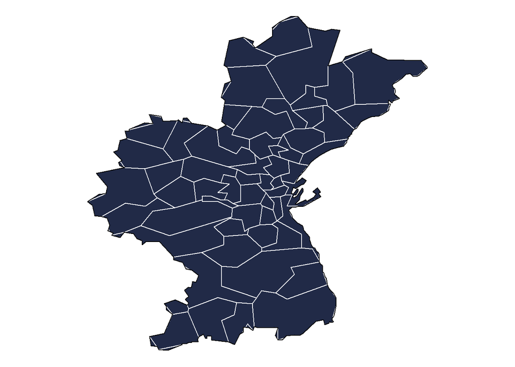

```r
# Draw the boarder of Aarhus
aa_base <- ggplot(data = aarhuscor, mapping = aes(x = long, y = lat, group = group)) + coord_fixed(1.3) +
  geom_polygon(color = "black", fill = "#212a47")

# Add white lines for the parishes
aa_base + theme_nothing() +
  geom_polygon(data = aarhus_mun, fill = NA, color = "white") +
  geom_polygon(color = "black", fill = NA)  # get the municipality border black
```

Add data for target group per gyms in each parish to see the differences

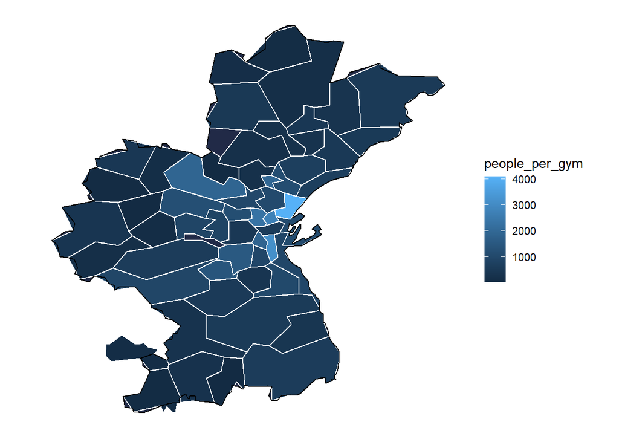

```r
ditch_the_axes <- theme(
  axis.text = element_blank(),
  axis.line = element_blank(),
  axis.ticks = element_blank(),
  panel.border = element_blank(),
  panel.grid = element_blank(),
  axis.title = element_blank()
  )

fitness_map <- aa_base +
      geom_polygon(data = aarhus_mun, aes(fill = people_per_gym), color = "white") +
      geom_polygon(color = "black", fill = NA) +
      theme_bw() +
      ditch_the_axes

fitness_map
```

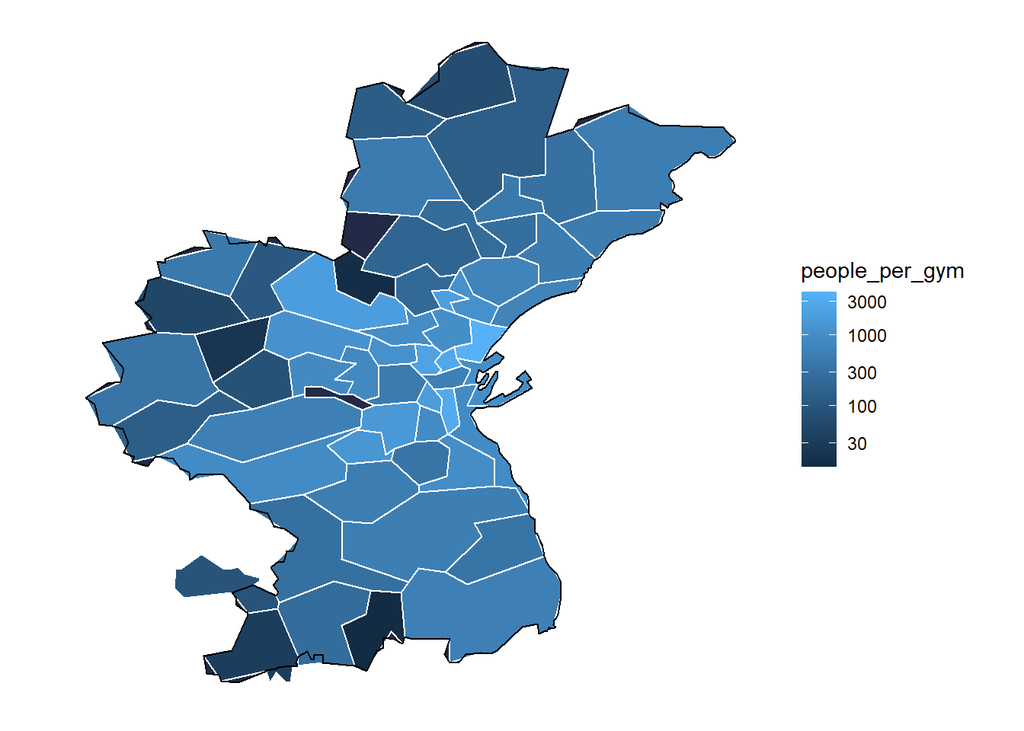

```r
# can also do scale transformation (easier to see parish differences)
fitness_map_scale = fitness_map + scale_fill_gradient(trans = "log10")

fitness_map_scale
```

Find the three centers with the biggest potential market/demand. Found by looking at data

```r
#Sankt Johannes
johannes <- subset(aarhus_mun, id=='sankt johannes')

#Sankt Lukas
lukas <- subset(aarhus_mun, id=='sankt lukas')

#Sankt Markus
markus <- subset(aarhus_mun, id=='sankt markus')
```

Mark them on the map

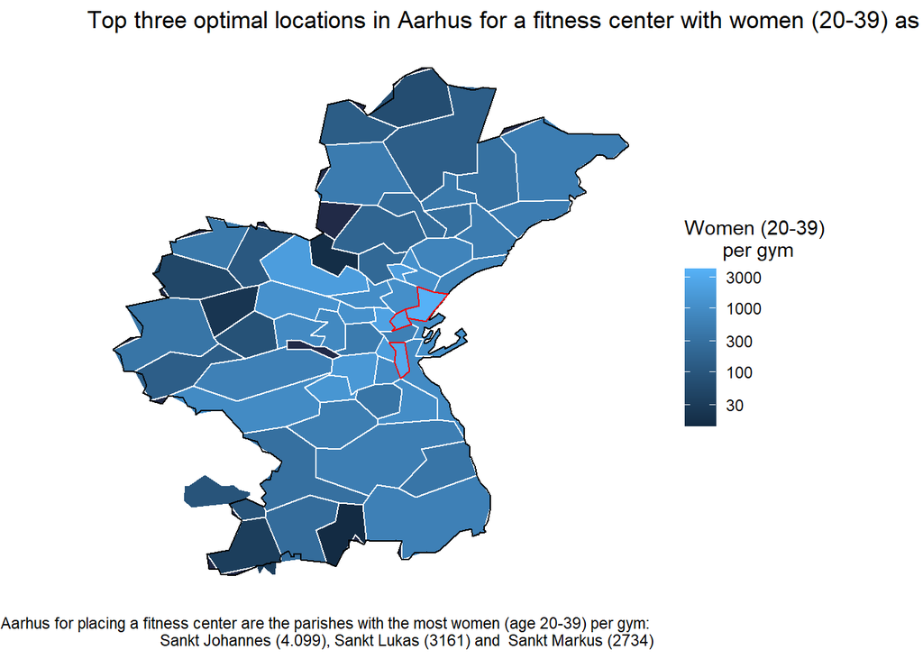

```r
one <- fitness_map_scale + geom_polygon(data = johannes, fill = NA, color = "red")
two  <- one + geom_polygon(data = lukas, fill = NA, color = "red")
three <- two + geom_polygon(data = markus, fill = NA, color = "red")
three + labs(
       title = "Top three optimal locations in Aarhus for a fitness center with women (20-39) as target group", fill = "Women (20-39)
       per gym", caption = "The three optimal parishes in Aarhus for placing a fitness center are the parishes with the most women (age 20-39) per gym:
       Sankt Johannes (4.099), Sankt Lukas (3161) and  Sankt Markus (2734)")
```